# Cross-sectional survey conducted with farmers on lameness occurrence in small-scale grazing dairy herds visited twice on the West part of Santa Catarina, Brazil, 2015

Jose Bran

2017

```r
library(ggplot2)
library(vcdExtra)
library(data.table)
library(epitools)
library(scales)
library(QCA)
library(car)
library(lme4)
library(plyr)
library(MASS)
library(multilevel)
library(car)
library(blmeco)
```

```r
survey <- read.csv("surv.csv")

View(survey)
```

#Describing data

#Workers per farm

```r
summary(survey$workers)
```

```
##    Min. 1st Qu.  Median    Mean 3rd Qu.    Max.
##   2.000   3.000   4.000   3.818   4.000   9.000
```

```r
sd(survey$workers)
```

```
## [1] 1.298886
```

#Age of manager

```r
summary(survey$age_man)
```

```
##    Min. 1st Qu.  Median    Mean 3rd Qu.    Max.
##   23.00   32.50   42.50   40.89   46.75   60.00
```

```r
sd(survey$age_man)
```

```
## [1] 10.01677
```

#Schooling level of farmers

1= elementary 2= secundary 3= post-secundary

```r
count(survey$school)
```

```
##   x freq
## 1 1   11
## 2 2   22
## 3 3   11
```

#For how long the farmers have been engaged in dairy production?

```r
summary(survey$years_prod)
```

```
##    Min. 1st Qu.  Median    Mean 3rd Qu.    Max.
##    5.00   15.00   20.00   20.34   25.25   35.00
```

```r
sd(survey$years_prod)
```

```
## [1] 7.517246
```

#Herd size

```r
summary(survey$milk.cows.1)
```

```
##    Min. 1st Qu.  Median    Mean 3rd Qu.    Max.
##   24.00   31.75   35.00   37.61   41.25   67.00
```

```r
sd(survey$milk.cows.1)
```

```
## [1] 9.170772
```

```r
summary(survey$milk.cows.2)
```

```
##    Min. 1st Qu.  Median    Mean 3rd Qu.    Max.
##   28.00   32.75   38.50   41.89   49.00   74.00
```

```r
sd(survey$milk.cows.2)
```

```
## [1] 11.22335
```

#Farmer estimated lameness prevalence

```r
summary(survey$farmer.prev.1)
```

```
##    Min. 1st Qu.  Median    Mean 3rd Qu.    Max.
##   0.000   3.130   5.710   6.543   8.453  25.000
```

```r
sd(survey$farmer.prev.1)
```

```
## [1] 5.260899
```

PS: One missing data on second visit

```r
summary(survey$farmer.prev.2)
```

```
##    Min. 1st Qu.  Median    Mean 3rd Qu.    Max.    NA's
##   0.000   0.000   2.940   3.756   6.225  15.790       1
```

```r
sd(survey$farmer.prev.2, na.rm = T)
```

```
## [1] 3.706175
```

# Questionnaire conducted with farmers:

#A. Is lameness the main health problem of lactating cows in your farm?

```r
count(survey$lam_hf)
```

```
##   x freq
## 1 N   37
## 2 Y    7
```

```r
7/44*100
```

```
## [1] 15.90909
```

##Table occurrence of vet estimated lameness by categories of answers

```r
ddply(survey, c("lam_hf"), summarize, lam.mainp1 = mean(clin.lam.1, na.rm=T),
      std = sd(clin.lam.1, na.rm=T),
      n = sum(!is.na(clin.lam.1)),
      med= median(clin.lam.1,na.rm=T),
      se = std/sqrt(n))
```

```
##   lam_hf lam.mainp1      std  n   med       se
## 1      N   29.71405 15.33251 37 27.78 2.520649
## 2      Y   37.89571 12.69411  7 36.36 4.797923
```

```r
ddply(survey, c("lam_hf"), summarize, lam.mains1 = mean(sev.lam.1, na.rm=T),
      std = sd(sev.lam.1, na.rm=T),
      n = sum(!is.na(clin.lam.1)),
      med= median(sev.lam.1,na.rm=T),
      se = std/sqrt(n))
```

```
##   lam_hf lam.mains1      std  n   med       se
## 1      N   13.95919 13.52856 37 11.11 2.224081
## 2      Y   16.73286 10.81349  7 12.12 4.087115
```

# B. Is lameness one out of the three most common health problems of lactating cows in your farm?

```r
count(survey$lam_h)
```

```
##   x freq
## 1 N   21
## 2 Y   23
```

```r
23/44*100
```

```
## [1] 52.27273
```

#Tables: prevalence of vet estimated lameness by category of answers

```r
ddply(survey, c("lam_h"), summarize, lam.o. = mean(clin.lam.1, na.rm=T),
      std = sd(clin.lam.1, na.rm=T),
      n = sum(!is.na(clin.lam.1)),
      med= median(clin.lam.1,na.rm=T),
      se = std/sqrt(n))
```

```
##   lam_h   lam.o.      std  n   med       se
## 1     N 26.37381 11.96351 21 24.32 2.610653
## 2     Y 35.25391 16.64581 23 33.33 3.470891
```

```r
ddply(survey, c("lam_h"), summarize, lam.o. = mean(sev.lam.1, na.rm=T),
      std = sd(sev.lam.1, na.rm=T),
      n = sum(!is.na(sev.lam.1)),
      med= median(sev.lam.1,na.rm=T),
      se = std/sqrt(n))
```

```
##   lam_h   lam.o.       std  n   med       se
## 1     N 10.51333  8.206633 21  9.30 1.790834
## 2     Y 17.94957 15.640377 23 12.12 3.261244
```

# C Is lameness the main reason for culling cows in your farm?

```r
count(survey$cull_lamfi)
```

```
##   x freq
## 1 N   40
## 2 Y    4
```

```r
4/44*100
```

```
## [1] 9.090909
```

#Tables: prevalence of vet estimated lameness by category of answers

```r
ddply(survey, c("cull_lamfi"), summarize, cull.fi = mean(clin.lam.1, na.rm=T),
      std = sd(clin.lam.1, na.rm=T),
      n = sum(!is.na(clin.lam.1)),
      med= median(clin.lam.1,na.rm=T),
      se = std/sqrt(n))
```

```
##   cull_lamfi cull.fi      std  n    med       se
## 1          N 30.4185 14.97443 40 28.705 2.367666
## 2          Y 36.9875 17.53031  4 36.860 8.765154
```

```r
ddply(survey, c("cull_lamfi"), summarize, cull.fi = mean(sev.lam.1, na.rm=T),
      std = sd(sev.lam.1, na.rm=T),
      n = sum(!is.na(sev.lam.1)),
      med= median(sev.lam.1,na.rm=T),
      se = std/sqrt(n))
```

```
##   cull_lamfi cull.fi       std  n    med       se
## 1          N 14.3255 13.491102 40 11.505 2.133131
## 2          Y 15.1500  8.846992  4 13.945 4.423496
```

#D. Is lameness one out of the three common reasons for culling cows in your farm?

```r
count(survey$cull_lam)
```

```
##   x freq
## 1 N   29
## 2 Y   15
```

```r
15/44*100
```

```
## [1] 34.09091
```

##Tables: prevalence of vet estimated lameness by category of answers

```r
ddply(survey, c("cull_lam"), summarize, cull = mean(clin.lam.1, na.rm=T),
      std = sd(clin.lam.1, na.rm=T),
      n = sum(!is.na(clin.lam.1)),
      med= median(clin.lam.1,na.rm=T),
      se = std/sqrt(n))
```

```
##   cull_lam     cull      std  n   med       se
## 1        N 26.42828 12.08492 29 24.32 2.244114
## 2        Y 39.88467 16.78546 15 36.36 4.333988
```

```r
ddply(survey, c("cull_lam"), summarize, cull = mean(sev.lam.1, na.rm=T),
      std = sd(sev.lam.1, na.rm=T),
      n = sum(!is.na(sev.lam.1)),
      med= median(sev.lam.1,na.rm=T),
      se = std/sqrt(n))
```

```
##   cull_lam     cull      std  n   med       se
## 1        N 10.60172 10.37753 29  8.33 1.927060
## 2        Y 21.74467 14.86297 15 16.13 3.837603
```

#Veterinary support: do you have any veterinarian support frequently? occassional?

```r
count(survey$asi_vet)
```

```
##                                                    x freq
## 1                a_cada_23_mese espec_fica_reprodu_o    1
## 2                      a_cada_23_mese s_quando_preci    2
## 3 a_cada_23_mese s_quando_preci espec_fica_reprodu_o    1
## 4                                          a_cada_ms    4
## 5                     a_cada_ms espec_fica_reprodu_o    4
## 6                           a_cada_ms s_quando_preci    4
## 7      a_cada_ms s_quando_preci espec_fica_reprodu_o   11
## 8                                     s_quando_preci   17
```

#Continued education: any course on animal health on last two years?

```r
survey$conti_for2years <- ifelse(survey$conti_for2years=="Y", "Y","N")
count(survey$conti_for2years)
```

```
##   x freq
## 1 N   24
## 2 Y   20
```

```r
count(survey$temtica_form)
```

```
##                              x freq
## 1         febre_do_leite outro    1
## 2                      mastite    2
## 3                mastite outro    5
## 4                        outro    5
## 5               sanidade_geral    3
## 6       sanidade_geral mastite    1
## 7 sanidade_geral mastite outro    2
## 8         sanidade_geral outro    1
## 9                         <NA>   24
```

#Univariable associations between answers and vet’s estimated lameness

```r
cows_nonlame.vet<- survey$Lstot.1-survey$LS_clin.1
```

```r
lame_nonlame.vet<-cbind(survey$LS_clin.1, cows_nonlame.vet)
```

```r
lame_nonlame.vet.sev<-cbind(survey$LS_sev.1, cows_nonlame.vet)
```

#Simple models (non mixed) or mixed effects model using municipality (town) as random effect were overdispersed

#Including an overdispersion term in the model to account for overdispersion *#*i.e., an observation-level random factor #Korner-Nievergelt et al., 2015 Chapter 8, 125 p.

```r
farm<-factor(survey$farm)
town<-survey$town
```

```r
summary(questions.vet_BM<-glmer(lame_nonlame.vet ~ survey$lam_hf + (1|town/farm), family= "binomial"))
```

```
## Generalized linear mixed model fit by maximum likelihood (Laplace
##   Approximation) [glmerMod]
##  Family: binomial  ( logit )
## Formula: lame_nonlame.vet ~ survey$lam_hf + (1 | town/farm)
##
##       AIC       BIC    logLik -2*log(L)  df.resid
##     273.0     280.1    -132.5     265.0        40
##
## Scaled residuals:
##      Min       1Q   Median       3Q      Max
## -1.00886 -0.34542 -0.02246  0.24689  1.25862
##
## Random effects:
##  Groups    Name        Variance Std.Dev.
##  farm:town (Intercept) 0.32452  0.5697
##  town      (Intercept) 0.05269  0.2295
## Number of obs: 44, groups:  farm:town, 44; town, 12
##
## Fixed effects:
##                Estimate Std. Error z value Pr(>|z|)
## (Intercept)     -0.9066     0.1565  -5.793 6.92e-09 ***
## survey$lam_hfY   0.4129     0.2868   1.440     0.15
## ---
## Signif. codes:  0 '***' 0.001 '**' 0.01 '*' 0.05 '.' 0.1 ' ' 1
##
## Correlation of Fixed Effects:
##             (Intr)
## srvy$lm_hfY -0.369
```

```r
exp(fixef(questions.vet_BM))
```

```
##    (Intercept) survey$lam_hfY
##      0.4038952      1.5111562
```

```r
exp(confint(questions.vet_BM, method= "Wald"))
```

```
##                    2.5 %    97.5 %
## .sig01                NA        NA
## .sig02                NA        NA
## (Intercept)    0.2972012 0.5488921
## survey$lam_hfY 0.8614136 2.6509834
```

```r
Anova(questions.vet_BM)
```

```
## Analysis of Deviance Table (Type II Wald chisquare tests)
##
## Response: lame_nonlame.vet
##                Chisq Df Pr(>Chisq)
## survey$lam_hf 2.0729  1     0.1499
```

assessing goodness of fit

```r
dispersion_glmer(questions.vet_BM)
```

```
## [1] 0.9847748
```

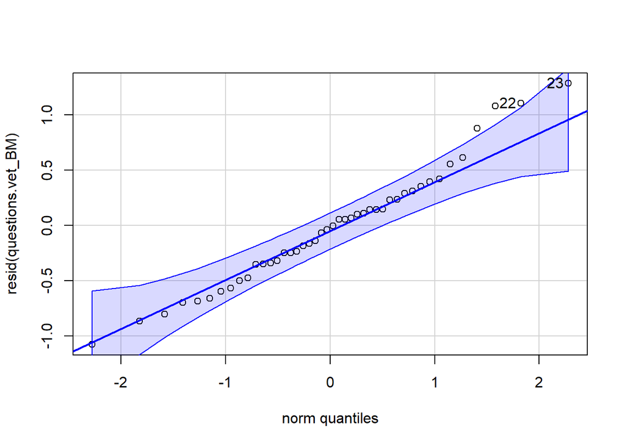

```
## [1] 23 22
```

```r
qqPlot(resid(questions.vet_BM))
```

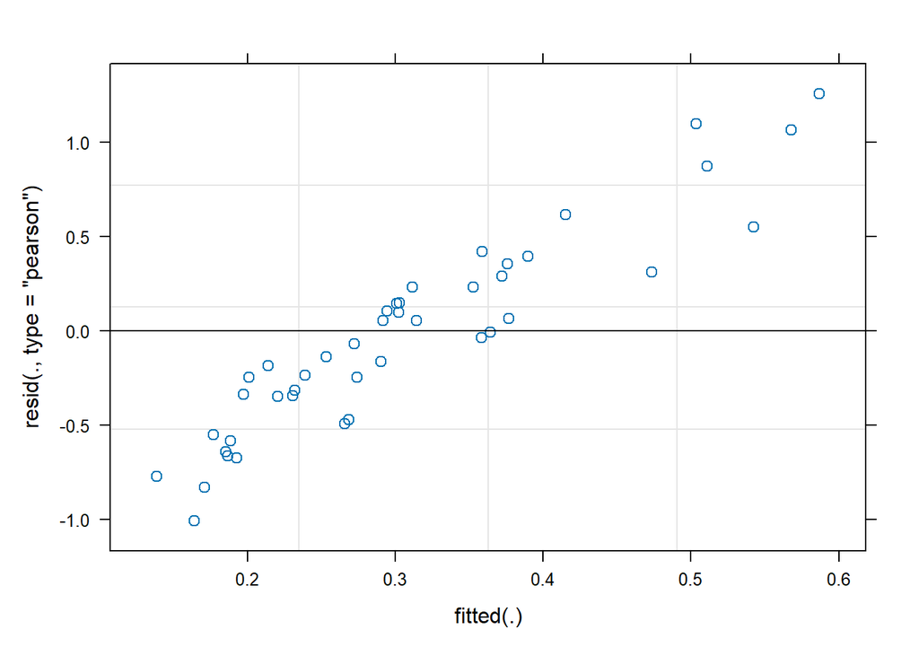

```r
plot(questions.vet_BM)
```

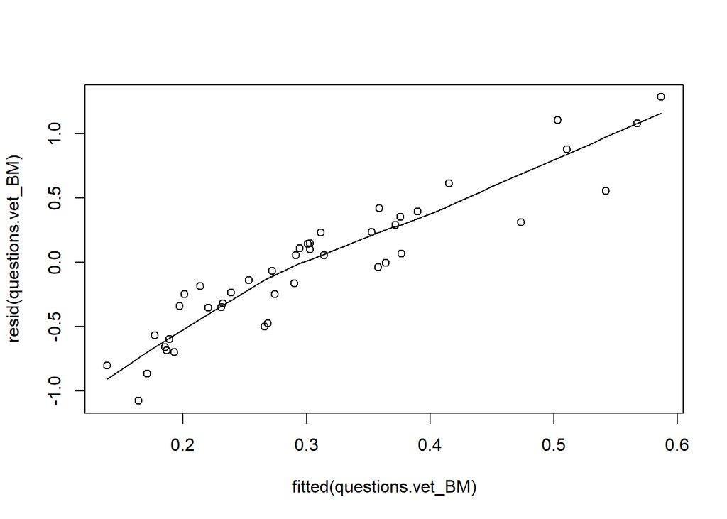

```r
scatter.smooth(fitted(questions.vet_BM), resid(questions.vet_BM))
```

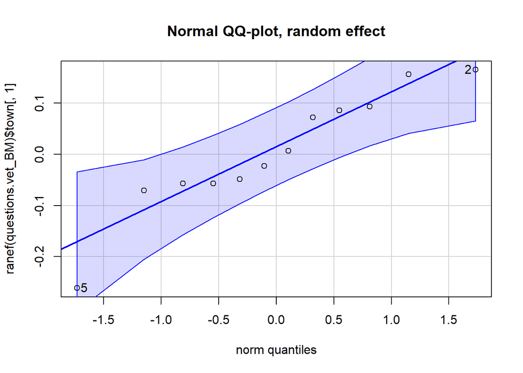

```
## [1] 5 2
```

```r
qqPlot(ranef(questions.vet_BM)$town[,1],
       main = "Normal QQ-plot, random effect")
```

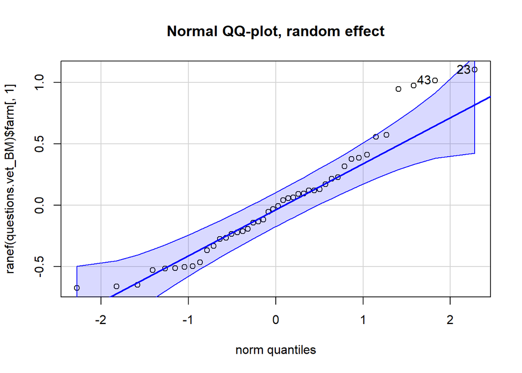

```
## [1] 23 43
```

```r
qqPlot(ranef(questions.vet_BM)$farm[,1],
       main = "Normal QQ-plot, random effect")
```

```r
summary(questions.vet_CM<-glmer(lame_nonlame.vet ~ survey$lam_h + (1|town/farm),  family= "binomial"))
```

```
## Generalized linear mixed model fit by maximum likelihood (Laplace
##   Approximation) [glmerMod]
##  Family: binomial  ( logit )
## Formula: lame_nonlame.vet ~ survey$lam_h + (1 | town/farm)
##
##       AIC       BIC    logLik -2*log(L)  df.resid
##     270.3     277.4    -131.1     262.3        40
##
## Scaled residuals:
##      Min       1Q   Median       3Q      Max
## -1.13847 -0.42190 -0.00624  0.33870  1.10291
##
## Random effects:
##  Groups    Name        Variance Std.Dev.
##  farm:town (Intercept) 0.2612   0.5111
##  town      (Intercept) 0.1150   0.3391
## Number of obs: 44, groups:  farm:town, 44; town, 12
##
## Fixed effects:
##               Estimate Std. Error z value Pr(>|z|)
## (Intercept)    -1.0172     0.1862  -5.464 4.65e-08 ***
## survey$lam_hY   0.4548     0.1989   2.287   0.0222 *
## ---
## Signif. codes:  0 '***' 0.001 '**' 0.01 '*' 0.05 '.' 0.1 ' ' 1
##
## Correlation of Fixed Effects:
##             (Intr)
## survy$lm_hY -0.503
```

```r
exp(fixef(questions.vet_CM))
```

```
##   (Intercept) survey$lam_hY
##     0.3615991     1.5758797
```

```r
exp(confint(questions.vet_CM, method= "Wald"))
```

```
##                   2.5 %    97.5 %
## .sig01               NA        NA
## .sig02               NA        NA
## (Intercept)   0.2510557 0.5208163
## survey$lam_hY 1.0671530 2.3271235
```

```r
Anova(questions.vet_CM)
```

```
## Analysis of Deviance Table (Type II Wald chisquare tests)
##
## Response: lame_nonlame.vet
##               Chisq Df Pr(>Chisq)
## survey$lam_h 5.2292  1    0.02221 *
## ---
## Signif. codes:  0 '***' 0.001 '**' 0.01 '*' 0.05 '.' 0.1 ' ' 1
```

Assessing goodness of fit

```r
dispersion_glmer(questions.vet_CM)
```

```
## [1] 0.9830258
```

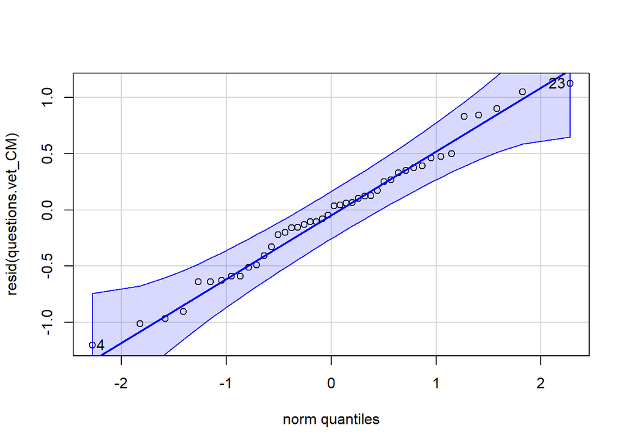

```
## [1]  4 23
```

```r
qqPlot(resid(questions.vet_CM))
```

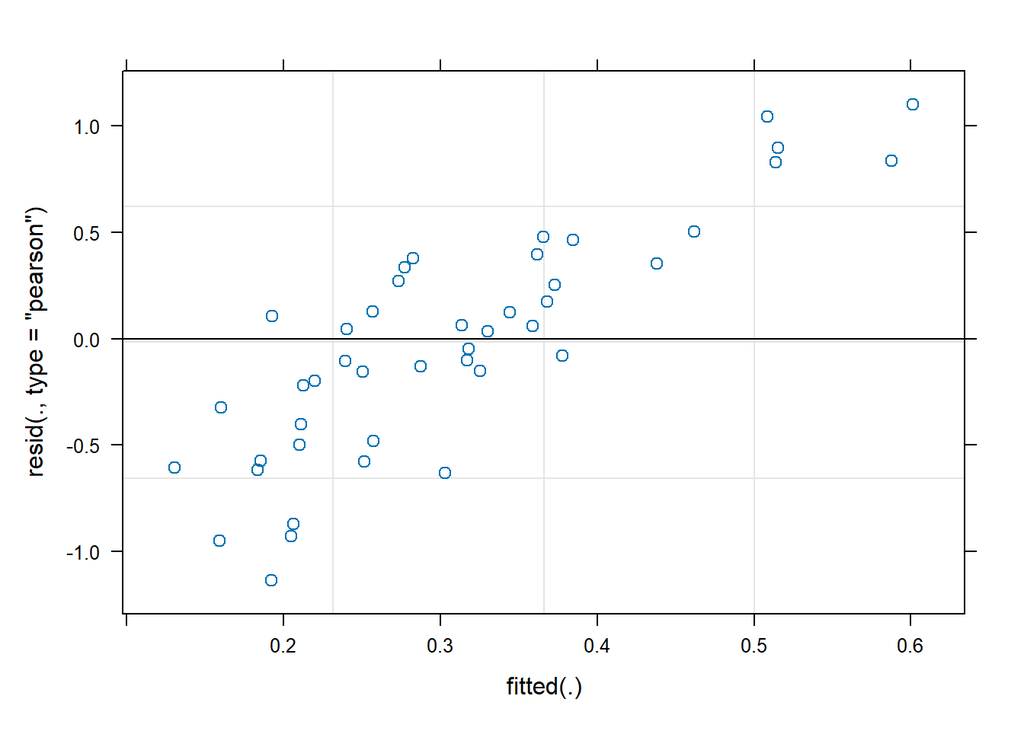

```r
plot(questions.vet_CM)
```

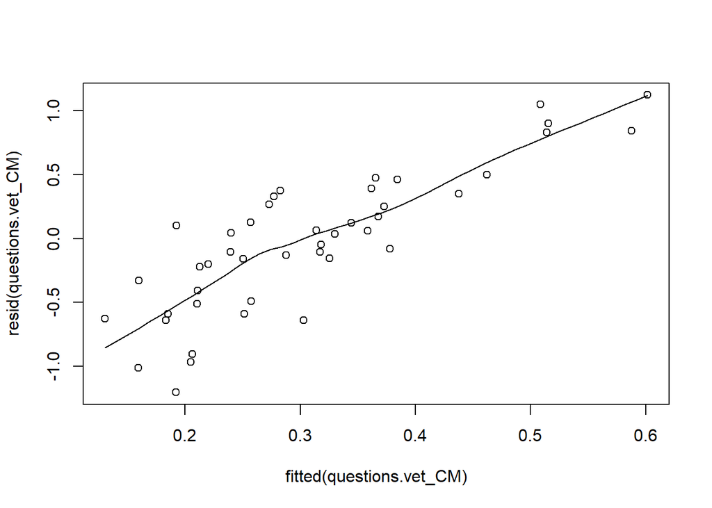

```r
scatter.smooth(fitted(questions.vet_CM), resid(questions.vet_CM))
```

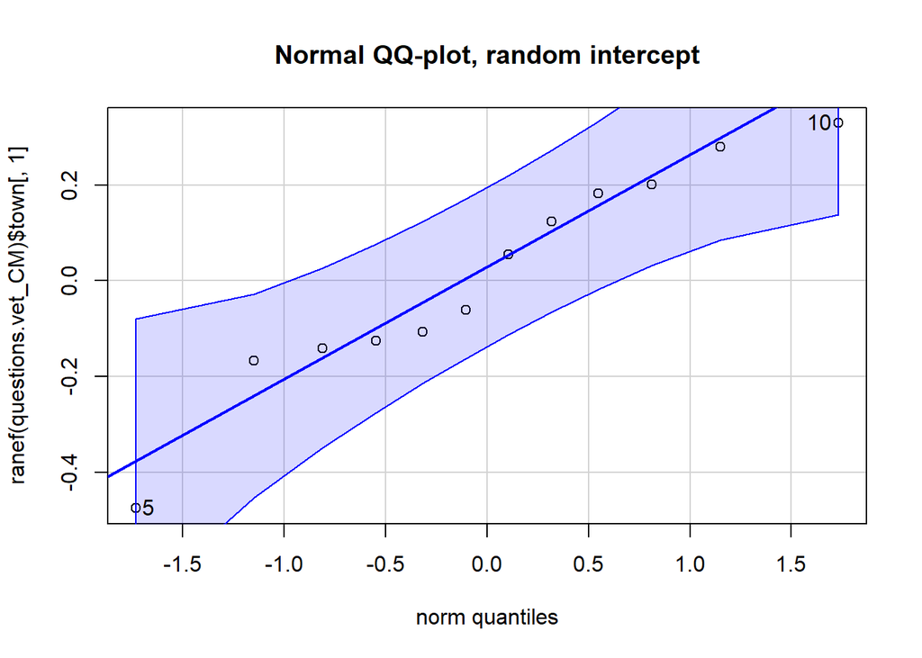

```
## [1]  5 10
```

```r
qqPlot(ranef(questions.vet_CM)$town[,1],
       main = "Normal QQ-plot, random intercept")
```

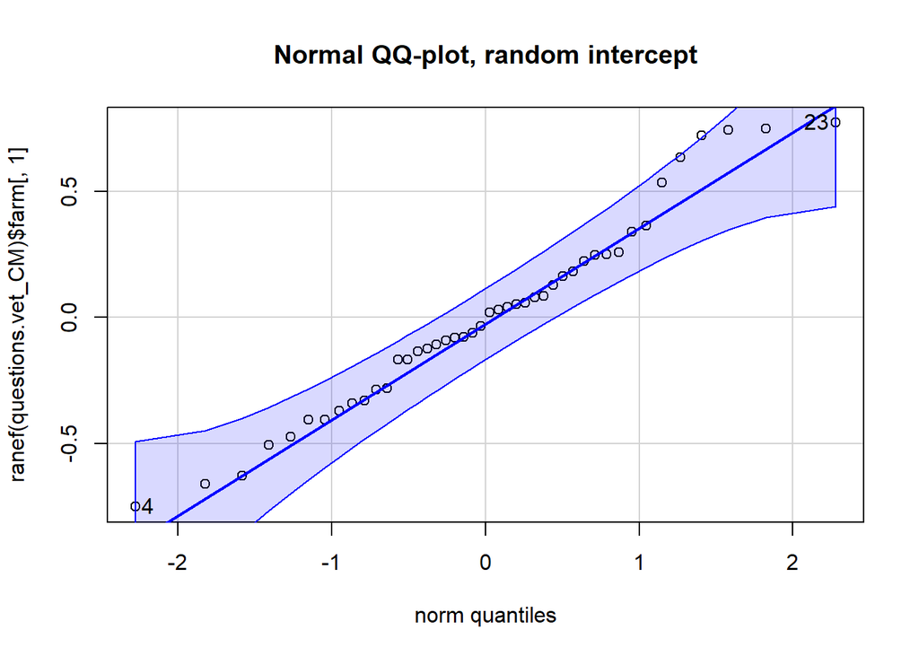

```
## [1] 23  4
```

```r
qqPlot(ranef(questions.vet_CM)$farm[,1],
       main = "Normal QQ-plot, random intercept")
```

```r
summary(questions.vet_DM<-glmer(lame_nonlame.vet ~ survey$cull_lamfi + (1|town/farm), family= "binomial"))
```

```
## Generalized linear mixed model fit by maximum likelihood (Laplace
##   Approximation) [glmerMod]
##  Family: binomial  ( logit )
## Formula: lame_nonlame.vet ~ survey$cull_lamfi + (1 | town/farm)
##
##       AIC       BIC    logLik -2*log(L)  df.resid
##     274.4     281.5    -133.2     266.4        40
##
## Scaled residuals:
##      Min       1Q   Median       3Q      Max
## -1.01272 -0.33459  0.02705  0.23523  1.19272
##
## Random effects:
##  Groups    Name        Variance Std.Dev.
##  farm:town (Intercept) 0.34168  0.5845
##  town      (Intercept) 0.05289  0.2300
## Number of obs: 44, groups:  farm:town, 44; town, 12
##
## Fixed effects:
##                    Estimate Std. Error z value Pr(>|z|)
## (Intercept)         -0.8579     0.1566  -5.480 4.26e-08 ***
## survey$cull_lamfiY   0.2849     0.3708   0.768    0.442
## ---
## Signif. codes:  0 '***' 0.001 '**' 0.01 '*' 0.05 '.' 0.1 ' ' 1
##
## Correlation of Fixed Effects:
##             (Intr)
## srvy$cll_lY -0.285
```

```r
exp(fixef(questions.vet_DM))
```

```
##        (Intercept) survey$cull_lamfiY
##          0.4240446          1.3296304
```

```r
exp(confint(questions.vet_DM, method= "Wald"))
```

```
##                        2.5 %    97.5 %
## .sig01                    NA        NA
## .sig02                    NA        NA
## (Intercept)        0.3119956 0.5763345
## survey$cull_lamfiY 0.6428025 2.7503270
```

```r
Anova(questions.vet_DM)
```

```
## Analysis of Deviance Table (Type II Wald chisquare tests)
##
## Response: lame_nonlame.vet
##                    Chisq Df Pr(>Chisq)
## survey$cull_lamfi 0.5902  1     0.4423
```

Assessing goodness of fit

```r
dispersion_glmer(questions.vet_DM)
```

```
## [1] 0.9838654
```

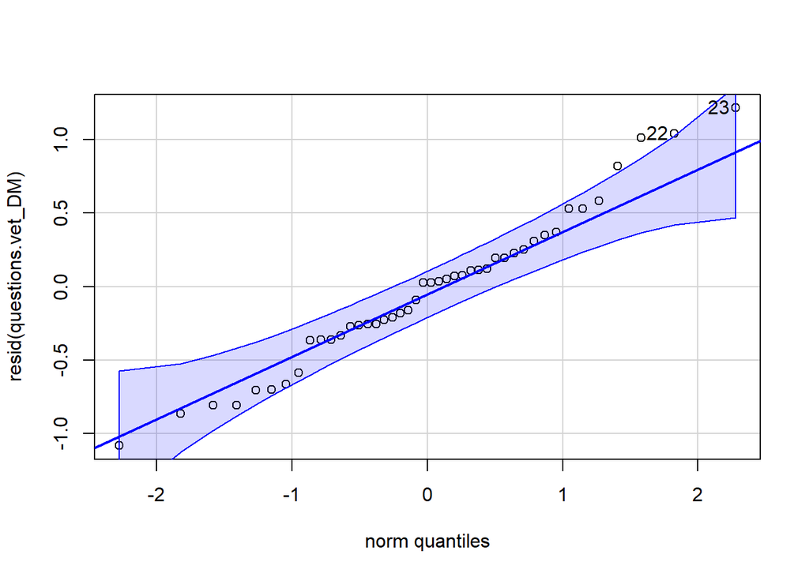

```
## [1] 23 22
```

```r
qqPlot(resid(questions.vet_DM))
```

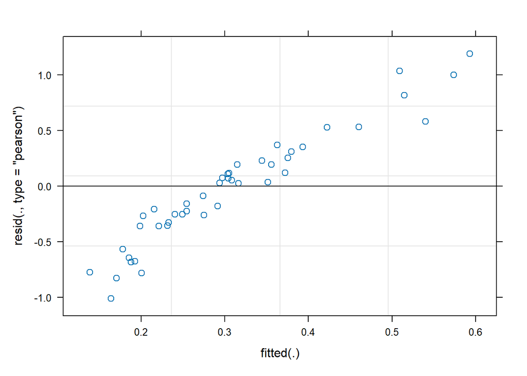

```r
plot(questions.vet_DM)
```

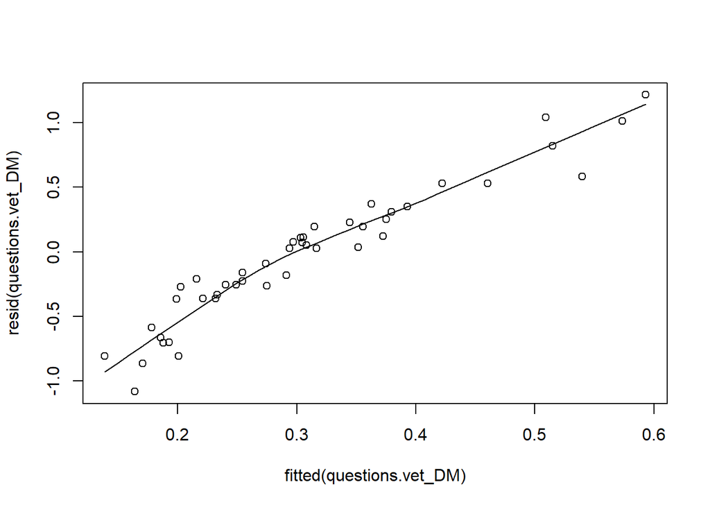

```r
scatter.smooth(fitted(questions.vet_DM), resid(questions.vet_DM))
```

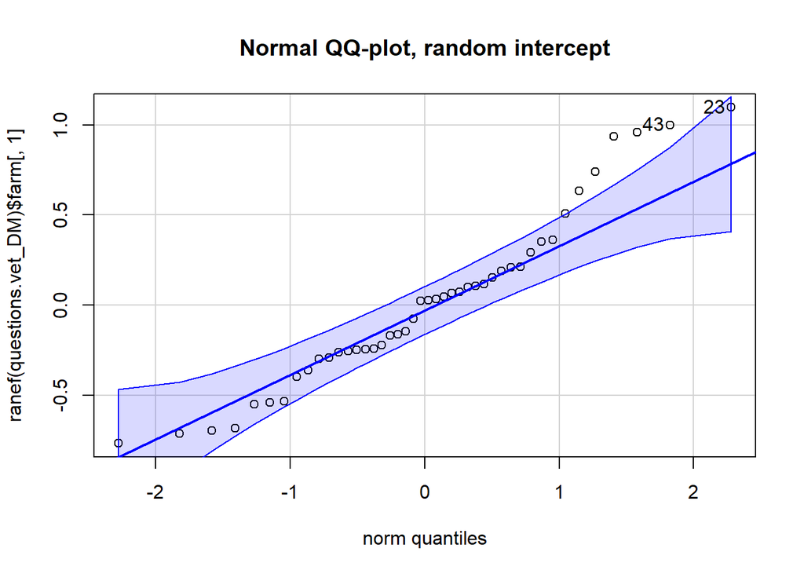

```
## [1] 23 43
```

```r
qqPlot(ranef(questions.vet_DM)$farm[,1],
       main = "Normal QQ-plot, random intercept")
```

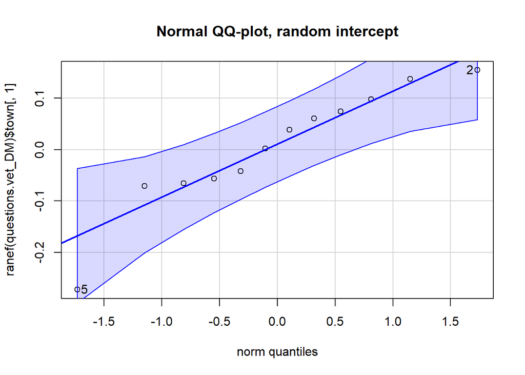

```
## [1] 5 2
```

```r
qqPlot(ranef(questions.vet_DM)$town[,1],
       main = "Normal QQ-plot, random intercept")
```

```r
summary(questions.vet_EM<-glmer(lame_nonlame.vet ~ survey$cull_lam + (1|town/farm), family= "binomial"))
```

```
## boundary (singular) fit: see help('isSingular')
```

```
## Generalized linear mixed model fit by maximum likelihood (Laplace
##   Approximation) [glmerMod]
##  Family: binomial  ( logit )
## Formula: lame_nonlame.vet ~ survey$cull_lam + (1 | town/farm)
##
##       AIC       BIC    logLik -2*log(L)  df.resid
##     266.3     273.5    -129.2     258.3        40
##
## Scaled residuals:
##      Min       1Q   Median       3Q      Max
## -0.99823 -0.44141 -0.03229  0.31156  1.33148
##
## Random effects:
##  Groups    Name        Variance  Std.Dev.
##  farm:town (Intercept) 2.916e-01 5.400e-01
##  town      (Intercept) 2.301e-10 1.517e-05
## Number of obs: 44, groups:  farm:town, 44; town, 12
##
## Fixed effects:
##                  Estimate Std. Error z value Pr(>|z|)
## (Intercept)       -1.1011     0.1249  -8.814  < 2e-16 ***
## survey$cull_lamY   0.6543     0.2071   3.159  0.00158 **
## ---
## Signif. codes:  0 '***' 0.001 '**' 0.01 '*' 0.05 '.' 0.1 ' ' 1
##
## Correlation of Fixed Effects:
##             (Intr)
## srvy$cll_lY -0.602
## optimizer (Nelder_Mead) convergence code: 0 (OK)
## boundary (singular) fit: see help('isSingular')
```

```r
exp(fixef(questions.vet_EM))
```

```
##      (Intercept) survey$cull_lamY
##        0.3325207        1.9238166
```

```r
exp(confint(questions.vet_EM, method= "Wald"))
```

```
##                      2.5 %    97.5 %
## .sig01                  NA        NA
## .sig02                  NA        NA
## (Intercept)      0.2603058 0.4247697
## survey$cull_lamY 1.2818809 2.8872186
```

```r
dispersion_glmer(questions.vet_EM)
```

```
## [1] 0.9903174
```

```r
Anova(questions.vet_EM)
```

```
## Analysis of Deviance Table (Type II Wald chisquare tests)
##
## Response: lame_nonlame.vet
##                  Chisq Df Pr(>Chisq)
## survey$cull_lam 9.9781  1   0.001584 **
## ---
## Signif. codes:  0 '***' 0.001 '**' 0.01 '*' 0.05 '.' 0.1 ' ' 1
```